# Shiny Retirement

7/13/2017

## Shiny Retirement App

- Though America is aging, millions of Americans have not saved enough for retirement. Some haven't even begun to save. This simple Shiny app can start people on the right path.
- By manipulating some basic information, a user can see just how different factors can influence their retirement savings.
- Play around with it and find a way to have a Shiny Retirement!

## A Retirement Example

- Let's say you are currently 20 years old and plan to retire at 65.
- You have already saved $10,000 and plan to put an additional $6,000 in the account each year.
- You are expecting a return of 6% and an inflation rate of 2%.
- After retirement, if you expect $1,000 each month in pensions and $5,000 in expenses, your money will last until you are about 91 years old.
- See what happens to your money in the graph on the next page.

## The Plot From Shiny Retirement

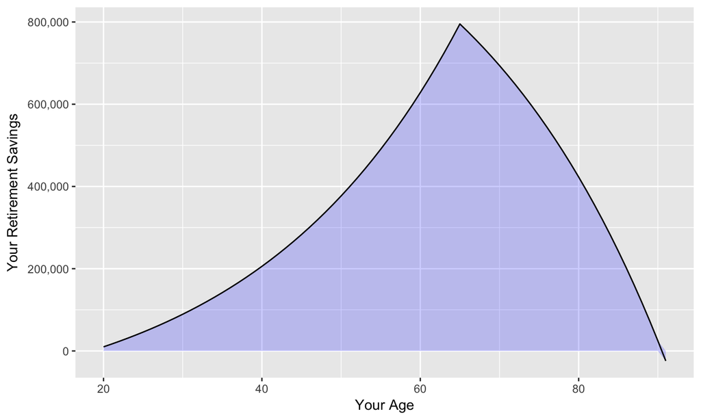

## Where Do I Find Shiny Retirement?

- The Shiny Retirement App can be accessed here: https://jgrantier.shinyapps.io/shiny_retirement/
- This presentation is available here: http://rpubs.com/jgrantier/291188
- The source code for the App (ui.R and server.R) and the Rmarkdown for this presentation can be found on GitHub: https://github.com/jgrantier/ShinyRetirement